# Experimental Sociology - Week 01

Introduction

Published

2025-04-09

# Course Overview

Welcome to the course! This week’s readings are heavily based on the slides presented during the first week. If you plan to attend (or have already attended) the session, you may notice that much of the material will feel familiar or even redundant. However, reviewing these readings can help reinforce key concepts.

## 🔍 What is This Course About?

- Hands on course that combines ES & CSS.
- Integrate analytical and computational methods:
  - **Analytical methods** – game theory & differential equations.
  - **Computational methods** – agent-based models (ABMs).
- These methods help us:
  - Derive **hypotheses**.
  - Enhance **experimental design**.

## 🏁 Goals

By the end of this course, you’ll:

- Understand how to model social situation analytically and computationally.
- Design, program, and modify ABMs.
- Derive theoretical guided (and empirically calibrated) hypotheses.
- Improve experimental design using analytical & computational methods.

## 🧩 Course Structure

- **Flipped Classroom Approach:**
  - 🏠 **Before class**: Read and study core concepts at your own pace.
  - 🏫 **In class**: Discuss, solve problems, and apply concepts.
- Mix of:
  - Hands-on coding.
  - Group work & discussions.
  - Problem-solving.

## 📖 Weekly Readings & Exercises

- Materials provided weekly at [sgrehl.github.io](https://sgrehl.github.io/).
- Some material might also be at [moodle](https://moodle2.uni-leipzig.de/course/view.php?id=53760).
- Read and engage with the assigned texts.
- Try to solve the exercises.
- Come to class prepared with questions and insights.

## 🛠️ Requirements

- **Sociological curiosity**
- **Laptop** – R and RStudio installed.
- **Basic R programming knowledge** – Comfortable with the basic, [tidyverse](https://www.tidyverse.org/learn/) & [functions](https://r4ds.had.co.nz/functions.html).
- **A sense of humor** – Things will break, code will crash, and the unexpected will happen.

## 🗣️ Communication

- Open communication is key – feel free to talk to us anytime.
- Questions or ideas? Reach out – we’re collaborators, not just instructors.
- This course is newly designed, so your feedback matters.

## 🗓️ Course Program

Our schedule:

- Week 1: Introduction
- Week 2–3: Analytical Solutions & (Evolutionary) Game Theory
- Week 4: ABMs: Basics
- Week 5–6: Evolutionary ABMs
- Week 7–9: Sensitivity Analysis & Calibration
- Week 10: **Machine Learning Basics**
- Week 11: **Open Lab Session**
- Week 12: Statistical Power & Experimental Design
- Week 13–14: Term Paper Presentations

# Progress in the Social Sciences

## 🎯 Learning Goals

By the end of this week, you should:

- Know the difference between **hypotheses** and **propositions**.
- Understand why **analytical solutions are valuable** in the social sciences.
- Recognize the **limitations of analytical solutions** when applied to complex social situations.
- What **advantages and limitations agent-based simulations** have.

## 🔬 The Ideal Research Process

Understanding how we advance knowledge in the social sciences begins with appreciating the **ideal research process** — a structured journey from theoretical intuition to empirical evidence.

1. **Formulating a Hypothesis**  
   We begin by developing a hypothesis — a testable prediction about how a treatment (or independent variable) influences a particular outcome (dependent variable).
2. **Running an Experiment**  
   This hypothesis is then put to the test through experimental or quasi-experimental methods, ideally involving random assignment to control for confounding variables.
3. **Estimating Models and Updating Knowledge**  
   After collecting data, we estimate statistical models to assess the evidence for our hypothesis, refining our theories and expectations based on what we find.

Despite this structured approach, there are two common challenges that often arise — both theoretical and practical.

### 💡 **How do we derive *good* hypotheses?**

A hypothesis is only as useful as the theoretical or conceptual reasoning behind it. If our hypotheses are vague, unfounded, or derived from shallow intuition, the resulting research may lack insight — even if it’s statistically sound.

**Example:**  
Consider the question of how social networks influence behavior. A well-formulated hypothesis might ask:

> *Does a highly clustered network structure lead to slower diffusion of innovation compared to a randomly connected one?*

This hypothesis is grounded in theory (network structure influences social learning and peer pressure) and is specific enough to test. But deriving it requires conceptual clarity about the mechanisms at play — and that’s not always straightforward.

### 📏 How do we *efficiently* test hypotheses?

Even when we have a good hypothesis, testing it can be statistically inefficient or infeasible. Many social phenomena are characterized by high variability, making it difficult to detect even meaningful effects.

**Example:**  
Suppose we hypothesize that increasing individuals’ income by 5% through a policy intervention leads to greater life satisfaction. But income data typically shows **high variance** — a wide spread in earnings across the population. In this case, a small treatment effect might be entirely obscured by the underlying noise.

To design a valid test, we would need to estimate:

- How large the effect must be to be statistically detectable?
- How large the sample size must be to achieve sufficient power?

Without this, we risk running studies that are underpowered and inconclusive — even if our hypothesis is correct.

Both problems highlight the importance of combining **strong theoretical reasoning** with **careful experimental design**. The future of social science progress lies not just in collecting more data, but in asking sharper questions and designing better tests.

## 🎓 From a Theory to a Hypothesis

- **Theory**: A systematically organized set of interrelated statements that explains and predicts phenomena (Braun 2008).
- **Model**: An representation of a formalized theory to address a specific problem.
- **Proposition**: Universal statement about the relationship between one or more concepts.
- **Hypothesis**: A specific, testable prediction.

## 🍪 Example

- **Theory**: Economic theory of Rational Choice.
- **Model:** Model of supply and demand.
- **Proposition**: When the price of a normal good rises, the demand for it falls.
- **Hypothesis:** If the price of rice rises, the demand for rice falls.

**Caution**

Experiments test hypotheses, not propositions.

## 🤔 Deriving a Hypothesis

According to Barrera et al. (2024, 52f), three major approaches exist for deriving hypotheses, as illustrated in Figure Figure 1.

[figure not shown]

Figure 1: Three distinct approaches to hypothesis generation, as outlined by Barrera et al. (2024, 52f).

Furthermore, I would like to distinguish model-driven approaches by whether they use a formal or a numerical methodology. Given that intuitive-driven approaches are less scientifically rigorous, we are left with three principal methods for deriving scientific hypotheses:

- **Logical Reasoning**  
  → Deductions based on existing theoretical assumptions and prior knowledge.
- **Formalized Model**  
  → Using structured frameworks or mathematical representations to explore implications.
- **Numerical Simulation**  
  → Simulating individual entities to observe emergent patterns within complex systems.

Let’s examine the strengths and limitations of each approach.

## 🎭 Tocqueville Paradox

Why does an **objective improvement in social conditions** lead to **greater dissatisfaction** (Tocqueville 2004, [1835])?

Stouffer et al. (1949) proposed an explanation based on **logical arguments**:

- Social change creates new opportunities for upward mobility (promotion).
- **Being promoted** is better than **not applying** for promotion.
- However, applying comes with costs – time, effort, risk of rejection:
  - Therefore, **not applying** is better than **being rejected**.
- As more people apply and only some succeed, dissatisfaction grows among those who fail.

*Dissatisfaction increases when objective conditions improve, because rising expectations aren’t met for a majority.*

### Tocqueville Paradox – A Closer Look

Not every social improvement triggers the Tocqueville Paradox.

So, **when** and **why** does it occur? Let’s explore:

- A TP is triggered if: **rejected > promoted**.
- A person is more likely to apply …
  - The more the **benefits outweigh the costs,**
  - The greater the perceived **chances of success**.
- **Success** increases when:
  - **More positions** for promotion are available,
  - **Fewer** others are **applying**.

### Tocqueville Paradox – DAG

Given this, we can derive a directed acyclic graph (DAG) representing the dynamics of the Paradox:

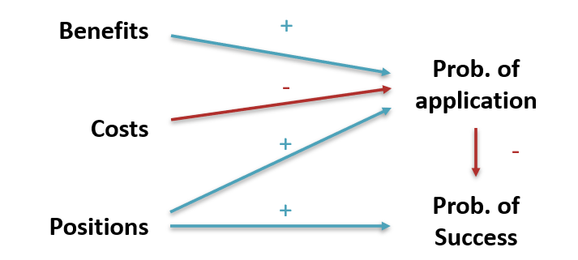

Figure 2: Proposed effect of benefits, costs, and positions on success probability. A Tocqueville Paradox occurs if the probabilty of sucess is under 50%.

The overall effect of increasing vacancies on success is **ambiguous** it depends on **how applicants respond**, as their behavior is **interdependent**!

### Formalized Model of Relative Frustration

Boudon (1977) developed the **model of relative frustration**, offering a game-theoretical perspective on promotion dynamics:

- $f$ be the share of positions available for promotion,
- $b$ the benefit of being promoted, and
- $c$ the cost of applying for a promotion.

Using a mixed-strategy Nash equilibrium, Boudon (1977) derives the following result:

The **optimal probability of applying**: $p = min \left( 1, f \cdot \frac{b}{c} \right)$

### Tocqueville Paradox – Visualization

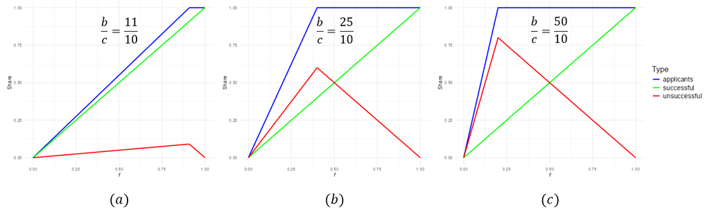

Figure 3: The impact of the benefit-cost ratio on the number of successful and unsuccessful applicants.

First, we observe that a **necessary condition** for a Tocqueville Paradox to emerge is that $f<0.5$ that is, the number of available opportunities (or vacancies) must be relatively scarce. Second, we find that only when the **benefit-cost ratio** satisfies $\frac{b}{c} > 2$, the share of **unsuccessful applicants** increases more sharply than the share of successful ones — a pattern that signals rising frustration in the presence of increasing opportunities.

Moreover, the **peak in the ratio of unsuccessful to successful individuals** shifts **leftward** as the benefit $b$ increases. In other words, the more attractive the opportunity, the **earlier** dissatisfaction peaks, relative to the overall number of opportunities. This dynamic illustrates a core intuition of the Tocqueville Paradox: improvements can amplify frustration under specific structural conditions.

Even if precise empirical estimation of parameters such as $b$ (benefit) and $c$ (cost) proves difficult in real-world settings, the model allows us to formulate testable hypotheses. For instance, we might expect that in societies where perceived benefits of mobility are high, frustration and perceived injustice may arise **earlier** in the process of social improvement — especially when structural bottlenecks (low $f$) persist. Thus, the model offers a powerful lens to explore the **nonlinear relationship** between opportunity structures and subjective perceptions of fairness or progress.

**Shiny code for this graph.**

```r
## server.R
library(shiny)
library(tidyverse)

shinyServer(function(input, output) {

  output$BoudonPlot <- renderPlot({

    mycolors = c("blue", "green", "red")

    cost <- 10
    df <- data.frame(vacant=(0:100)/100) %>%
      rowwise() %>%
      mutate(applicants   = min(1, vacant * (input$benefit/input$cost)))  %>%
      mutate(successful   = vacant,
             unsuccessful = applicants - vacant)

    # Reshape data to long format for ggplot
    df_long <- df %>%
      pivot_longer(cols = c(applicants, successful, unsuccessful), names_to = "type", values_to = "value")

    # Create ggplot
    ggplot(df_long, aes(x = vacant, y = value, color = type)) +
      geom_line(size = 1) +
      labs(
        title = "Vacant Positions vs. Applicants and Unsuccessful",
        x = expression(italic(f)),
        y = "Share",
        color = "Type"
      ) +
      scale_color_manual(values = mycolors) +
      theme_minimal() +
      theme(
        legend.text = element_text(size = 14),       # legend labels
        legend.title = element_text(size = 16)       # legend title
      )
  })

})
```

```r
## ui.R
library(shiny)

shinyUI(fluidPage(

  # Application title
  titlePanel("Boudon's Model of Relative Frustration"),

  # Sidebar with a slider input for number of bins
  sidebarLayout(
    inputPanel(
      sliderInput("benefit",
                  "Benefit:",
                  min = 10,
                  max = 50,
                  value = 25,
                  step = 1,
                  ),
      sliderInput("cost",
                  "Cost:",
                  min = 1,
                  max = 10,
                  value = 10,
                  step = 1,
      )
    ),

    # Show a plot of the generated distribution
    mainPanel(
      plotOutput("BoudonPlot")
    )
  )
))
```

## 🔑 Take-Away so Far

Logical Conclusions:

- **Simple and straightforward**: They offer an accessible method for deriving predictions.
- **Limited precision**: When verbal arguments point in different directions, their combined implications may become **ambiguous**, even if each argument is logically valid.

Formalized Models:

- **More complex**: Constructing these models requires a deeper level of analysis and rigor.

**Higher precision**: They can yield more nuanced and detailed predictions.

## 🧠 Why Analytical Solutions Matter

Analytical solutions (often expressed as equations) are the **gold standard** in science because:

- They provide **precise** answers.
- They allow for **clear causal interpretation**.
- They have a high **objectivity, transparency and reproducibility**.
- They are often **computationally fast**.

## ⚙️ Limitations with Formalized Models

- **Oversimplification**: Often reduce complex social realities to a few theoretical assumptions.
- **Homogeneity Assumption**: Often assumes little to no individual variation or social diversity.
- **Analytical Challenges with Complexity**: Addressing the above limitations often increases analytical complexity, potentially hindering the derivation of clear predictions (Balzer, Brendel, and Hofmann 2001).

But wait! There is a solution!

# Agent-Based Modeling (ABM)

## **🧪 What is ABM?**

Agent-Based Modeling (ABM) is a **microsimulation approach** used to explore how the actions and interactions of individual entities give rise to complex, collective patterns. Rather than modeling society or systems as a set of equations or averages, ABM starts at the micro level — with the behaviors, decisions, and characteristics of individual **agents**. These agents may represent people, groups, firms, or any other relevant unit of analysis, and each is defined by specific properties and decision rules that determine how they act and respond within the simulation.

At the heart of ABM are three key components:

- **Agents**: These are **autonomous decision-makers** with **individual traits**. Each agent can (to a certain extend) perceive its surroundings, follow specific rules, and adapt over time. The diversity of agents allows for the modeling of heterogeneity — a crucial aspect of real-world social systems.
- **Environment**: This refers to the **structured context** in which agents operate. It can be a spatial grid, a social **network**, or any abstract space that constrains or facilitates interaction. The environment shapes how agents encounter one another and can evolve as the simulation progresses. Note that even in simulations where no environment is explicitly defined, it is **often present implicitly** — for example, in the form of a complete network that connects every agent to every other.
- **Rules**: Rules define how agents behave, interact, and adapt within the environment. They specify **who interacts with whom** — for instance, whether an agent engages with all connected peers or only one at a time — and **how those interactions unfold**. Crucially, rules capture the logic by which individual decisions translate into system-level outcomes, often through **interdependent behaviors** where one agent’s actions influence others. Another important class of rules concerns **adaptation**: how agents change over time, such as updating their opinions, strategies, or even entering or exiting the system. These rules may be **simple or complex**, **deterministic or stochastic**, and together they are the engine that drives the model’s dynamic evolution.

By simulating many agents acting simultaneously over successive time steps, ABM allows researchers to observe **emergent phenomena** — collective patterns that are not directly programmed into the model but arise from local interactions. This makes ABM a powerful tool for investigating social dynamics, policy impacts, and systemic risks in fields ranging from sociology and economics to epidemiology and political science.

### A Schematic Example of an ABM

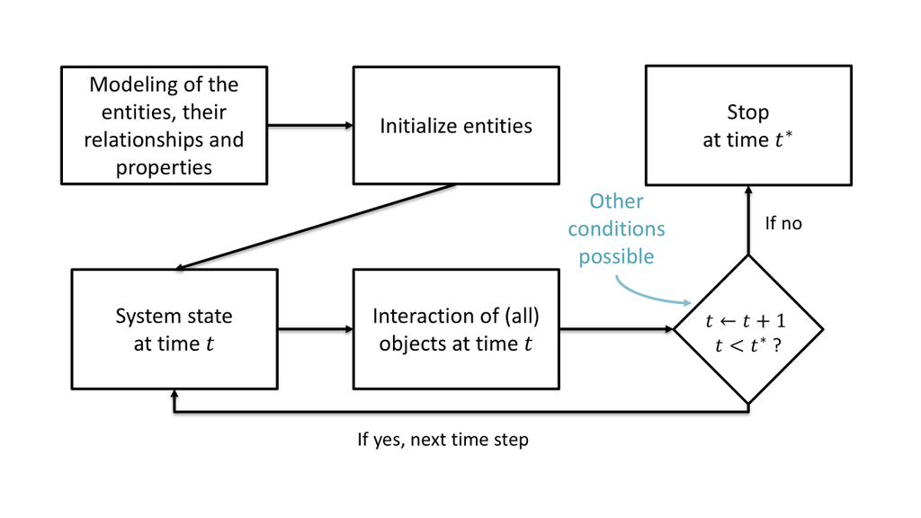

Figure 4: Basic steps for a agent-based model.

### 🧲 Example – The Schelling Model

Similar: 0%

Red/Blue: 0

Empty: 0%

Size: 0

Delay: 0ms

| Your browser must support JavaScript for the simulation to work. |
| --- |

Round: 0

Satisfied: 0 %

(This example is based on Schelling (1971), and builds extensively on the earlier work of [Frank McCown](http://nifty.stanford.edu/2014/mccown-schelling-model-segregation/))

### ❓Typical Research Questions

When employing an agent-based model (ABM), researchers typically aim to address multiple research questions. These models are instrumental in exploring how individual agent behaviors and interactions give rise to complex system-level patterns. In the case of the Schelling Model, for instance, such questions might include:

- What factors influence …
  - … whether the model terminates?
  - … how long (on average) it take to reach termination?
  - … how high the level of satisfaction or segregation is at termination or in the long run?
- What hypotheses can we derive from that for the real world?

## 🚀 Advantages of ABM

Casini and Manzo (2016) lists a number of advantages:

- **Flexibility**:
  - No fixed assumptions on agents, behaviors, or structures.
  - Components (mechanisms) can be added or removed individually.
- **Granularity**:
  - Modelers can define detail level for each element.
- **Generality**:
  - Supports multiple modeling formalisms.

### ⏱️ Time in ABMs

**Dynamic Evolution**: ABMs inherently simulate systems that evolve step-by-step over time, capturing the progression of processes at each stage.

**Pathway Analysis**: Beyond merely predicting end states (e.g., Nash equilibria), ABMs provide insights into the pathways leading to these outcomes, offering a comprehensive understanding of social developments.

**Activation Sequences**: The sequence in which agents act can significantly influence model outcomes. Researchers have the flexibility to experiment with different activation orders to observe varying effects.

**Temporal Structuring**: Time within ABMs can be explicitly configured. By adjusting temporal parameters and schedules (e.g., hours instead of days), diverse macro-level patterns can emerge, enhancing our understanding of temporal influences on system behavior.

### 🧪 Advantages of ABMs Over Empirical Studies

👥 **Studies** with real agents (i.e., humans):

- Costly and time-consuming.
- Difficult to execute.
- Sometimes unethical.

💻 **ABMs** as an alternative:

- Test hypotheses as **proof of concept**.
- Identify **crucial and irrelevant factors**.
- Does NOT replace empirical confirmation — use insights to design better real-world studies.

### 🔍 Other Advantages

- **Automated:**  
  Effects of changed parameters/other formalisms, do not have to be calculated, but can be implemented automatically.
- **Educational**:  
  Visualizations aid understanding.  
  Students can explore ABMs directly.

## ⚠️ Limitations and Challenges of ABMs

📉 **Methodological Disadvantages**

- **Limited Functional Transparency**: Functional relationships are typically *estimated*, not *analytically derived*.
- **Computational Intensity**: ABMs are *slower* and more resource-demanding than analytical solutions.

🛠️ **Practical Challenges**

- **Reproducibility Concerns**: *Lack of transparency* if source code is not open or clearly documented (seeding!).
- **Assumption Bias**: Model outcomes may *reflect embedded assumptions* rather than emergent behavior.
- **“Garbage In, Garbage Out”**: Poorly specified models yield misleading results (see also Grimm et al. 2020).

# Types & Aims of ABMs

## 🧠 Abstract ABMs

**Main Goal:** Gain **theoretical insights** into complex systems by simplifying reality.

**Design Principles:**

- **KISS (“Keep It Simple, Stupid!”)**:  
  Emphasizes simplicity to focus on fundamental mechanisms.
- **Parsimonious Models**:  
  Utilize minimal parameters and rules.
- **Non-Empirical Parameterization**:  
  Parameters are set without direct empirical calibration.

### Abstract ABMs II

**Objectives:**

- Observe general process dynamics to understand underlying mechanisms.
- Derive heuristics and logical implications.

**Example: Schelling’s Segregation Model**

- Represents residential areas as a 2D grid
- Defines agent (un)happiness based on neighboring agents’ group identity.
- **Value:** Provides profound insights into how individual preferences can lead to collective segregation patterns.

## 📊 Data-Driven ABMs

**Main Goal:** **Realistic simulations** that mirror empirical phenomena.

**Design Principles:**

- **KIDS (“Keep It Descriptive, Stupid!”)**: Prioritizes detailed, descriptive accuracy.
- **Replication of Empirical Observations**: Aims to reproduce observed phenomena through micro-founded simulations.
- **Iterative Adjustment**: Continuously calibrate parameters and structures to align model outcomes with empirical real-world data.

### Data-Driven ABMs II

**Objectives:**

- Explain concrete phenomena by grounding models in observed data.
- Validate model behavior against empirical patterns to increase credibility and predictive accuracy.
- Use simulation as a testing ground for theory under real-world constraints.
- Support policy-making or intervention design by modeling counterfactuals and scenario outcomes.

### Example: Diffusion of Innovation

- **Context:** Studied how innovations spread among farmers in Sweden (Hägerstrand 1965)
- **Assumptions:**
  - Adoption likelihood decreases with geographic distance.
  - Natural barriers (e.g., lakes, mountains) impede diffusion.
- **Incorporated Data:**
  - Actual geographic features of the study area.
  - Population distribution and initial locations of adopters.
- **Objective:** Simulate the diffusion trajectory of innovations.
- **Methodology:**
  - Adjusted model parameters until simulated diffusion matched observed patterns.

### Example: Diffusion of Innovation II

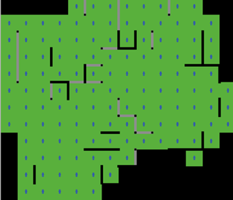

Figure 5: Idealisation of a province in Sweden. Reconstruction of the Model of Hägerstrand (1965).

# Final Thoughts

## Choosing the Right Tool

Finally, let us briefly draw our attention to one more problem. If you have been paying attention so far, you might get the impression that there is a strict hierarchy with regard to the approaches considered for hypothesis derivation and that simulations are the non-plus-ultra. However, as just mentioned, this is also associated with a number of disadvantages.

Not every problem requires a complex and computationally intensive simulation. In fact, applying sophisticated tools to simple problems can:

- Introduce unnecessary complexity
- Waste computational resources
- Obscure understanding
- Create the illusion of rigor where none is needed

### Practical Considerations

When selecting a method, ask yourself:

- **Is there an analytical solution?** If so, is it straightforward and more efficient?
- Does the complexity of the method match the complexity of the problem?
- What are the trade-offs?

### Monte Carlo Multiplication

First Number (0-10):

Second Number (0-10):

[interactive chart not shown]

Here, I present a Monte Carlo simulation that estimates the area of a rectangle on a 10×10 canvas. In essence, it’s a roundabout way to perform a simple multiplication — calculating width × height.

Instead of multiplying two numbers directly, this approach randomly “throws darts” at the canvas and counts how many land inside the rectangle to estimate its area. It’s a textbook example of using a powerful technique where it’s absolutely not needed. This simulation serves as a reminder:

**Tip**

🧠 Just because you can use a simulation it doesn’t mean you should.

Please consider whether you truly need a simulation — or if you might just need a calculator.

**R code for the Monte Carlo Muliplication.**

```r
# Define canvas dimensions
canvas_width <- 10
canvas_height <- 10

# Define the rectangle dimensions based on our two numbers
number_1 <- 6
number_2 <- 4

# Number of simulation points ("darts")
n_points <- 10000

# Set seed for reproducibility
set.seed(42)

# Generate random points uniformly distributed over the canvas
x <- runif(n_points, min = 0, max = canvas_width)
y <- runif(n_points, min = 0, max = canvas_height)

# Determine which points fall inside the number_2
inside <- (x <= number_1) & (y <= number_2)

# Estimate the area of the rectangle using the Monte Carlo method
estimated_area <- (sum(inside) / n_points) * (canvas_width * canvas_height)

# Calculate the true area of the rectangle
true_area <- number_1 * number_2

# Print the results
cat("Estimated Area:", estimated_area, "\n")
cat("True Area:", true_area, "\n")

text_label <- paste("Estimate:", round(estimated_area, 2))

# Plot the simulation: points inside the rectangle in blue, outside in red
plot(x, y, col = ifelse(inside, "blue", "red"), pch = 20,
     xlab = "X", ylab = "Y",
     main = paste0("Monte Carlo Simulation for Multiplying ", number_1, " and ", number_2, "\n (", text_label, ")" ))

# Draw the rectangle for reference
rect(0, 0, number_1, number_2, border = "green", lwd = 2)
```

## References

Balzer, Wolfgang, Karl R. Brendel, and Solveig Hofmann. 2001. “Bad Arguments in the Comparison of Game Theory and Simulation in Social Studies.” *Journal of Artificial Societies and Social Simulation* 4 (2).

Barrera, Davide, Klarita Gërxhani, Bernhard Kittel, Luis Miller, and Tobias Wolbring. 2024. *Experimental Sociology: Outline of a Scientific Field*. 1st ed. Cambridge University Press. https://doi.org/10.1017/9781009099653.

Boudon, Raymond. 1977. *The Unintended Consequences of Social Action*. London: Macmillan.

Braun, Norman. 2008. “Theorie in Der Soziologie.” *Soziale Welt* 59 (4): 373395.

Casini, Lorenzo, and Gianluca Manzo. 2016. “Agent-Based Models and Causality. A Methodological Appraisal.” Linköping, SWE.

Grimm, Volker, Steven F. Railsback, Christian E. Vincenot, Uta Berger, Cara Gallagher, Donald L. DeAngelis, Bruce Edmonds, et al. 2020. “The ODD Protocol for Describing Agent-Based and Other Simulation Models: A Second Update to Improve Clarity, Replication, and Structural Realism.” *Journal of Artificial Societies and Social Simulation* 23 (2): 7. https://doi.org/10.18564/jasss.4259.

Hägerstrand, Torsten. 1965. “A Monte Carlo Approach to Diffusion.” *European Journal of Sociology* 6 (1): 43–67. https://doi.org/10.1017/S0003975600001132.

Schelling, Thomas C. 1971. “On the Ecology of Micromotives.” *Public Interest* 25: 61–98.

Stouffer, Samuel A., Edward A. Suchman, Leland C. DeVinney, Shirley A. Star, and Robin M. Jr. Williams. 1949. *The American Soldier: Adjustment During Army Life. (Studies in Social Psychology in World War Ii).* Princeton: Princeton University Press.

Tocqueville, Alexis de. 2004. *Democracy in America: The Complete and Unabridged Volumes I and II*. New York: Bantam Dell.

## Copyright

Copyright Sascha Grehl, 2025. All Rights Reserved